# Bubble Sort

Bubble Sort adalah algoritma pengurutan paling sederhana yang bekerja dengan berulang kali menukar elemen yang berdekatan jika urutannya salah. Algoritma ini tidak efisien untuk kumpulan data besar karena kompleksitas waktu rata-rata dan terburuknya cukup tinggi.

Mengurutkan array menggunakan beberapa tahapan. Setelah tahapan pertama, nilai maksimum dipindahkan ke akhir (posisi yang benar). Dengan cara yang sama, setelah tahapan kedua, nilai terbesar kedua dipindahkan ke posisi kedua dari bawah, dan seterusnya. Pada setiap tahapan, proses hanya yang belum berpindah ke posisi yang benar. Setelah k tahapan, k terbesar harus telah dipindahkan ke k posisi terakhir. Dalam satu tahapan, kita mempertimbangkan elemen-elemen yang tersisa dan membandingkan semua elemen yang berdekatan, lalu menukar posisi jika elemen yang lebih besar berada sebelum elemen yang lebih kecil. Jika kita terus melakukan ini, kita akan mendapatkan elemen terbesar (di antara elemen-elemen yang tersisa) pada posisi yang benar.

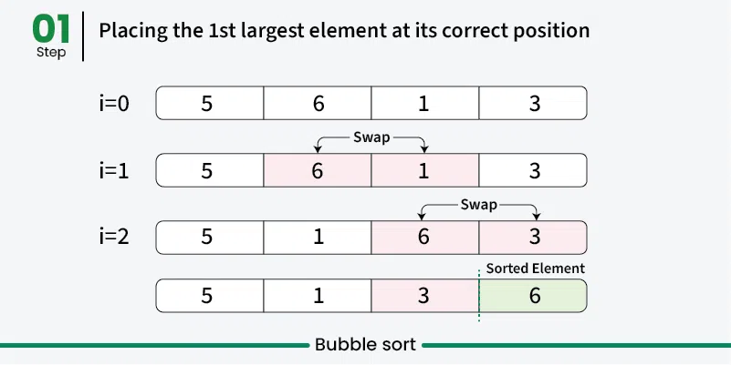

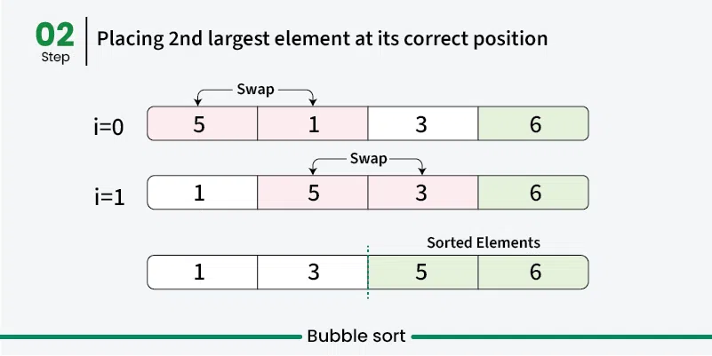

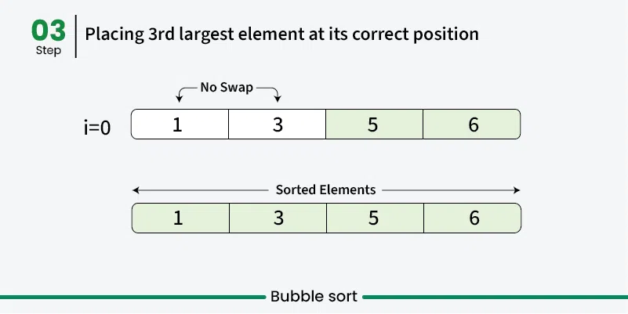

```
Berikut adalah implementasi dari algoritma bubble sort. Algoritma ini dapat dioptimalkan dengan menghentikan eksekusi jika loop dalam tidak menyebabkan pertukaran (swap).
```

```python
# Optimized Python program for implementation of Bubble Sort
def bubbleSort(arr):
    n = len(arr)

    # Traverse through all array elements
    for i in range(n):
        swapped = False

        # Last i elements are already in place
        for j in range(0, n-i-1):

            # Traverse the array from 0 to n-i-1
            # Swap if the element found is greater
            # than the next element
            if arr[j] > arr[j+1]:
                arr[j], arr[j+1] = arr[j+1], arr[j]
                swapped = True
        if (swapped == False):
            break

# Driver code to test above
if __name__ == "__main__":
    arr = [64, 34, 25, 12, 22, 11, 90]

    bubbleSort(arr)

    print("Sorted array:")
    for i in range(len(arr)):
        print("%d" % arr[i], end=" ")
```

```
Sorted array:
11 12 22 25 34 64 90
```

Analisis Kompleksitas Bubble Sort:

`Kompleksitas Waktu: O(n² ) Ruang`

`Tambahan: O(1)`

## Keunggulan Bubble Sort:

- Algoritma bubble sort mudah dipahami dan diimplementasikan.
- Ini tidak memerlukan ruang memori tambahan.
- Ini adalah algoritma pengurutan stabil, artinya elemen-elemen dengan nilai kunci yang sama mempertahankan urutan relatifnya dalam hasil pengurutan.

## Kekurangan dari Bubble Sort:

- Algoritma pengurutan gelembung (bubble sort) memiliki kompleksitas waktu O(n² ) yang membuatnya sangat lambat untuk kumpulan data yang besar.
- Algoritma pengurutan gelembung (bubble sort) hampir tidak memiliki atau hanya memiliki sedikit aplikasi di dunia nyata. Algoritma ini sebagian besar digunakan dalam bidang akademis untuk mengajarkan berbagai cara pengurutan.

## QUIZ OF BUBBLE SORT

#### 1. Berapakah kompleksitas waktu terbaik dari algoritma bubble sort (yang dioptimalkan)?

A. O(N^2)

B. O(NlogN)

C. 0(N)

D. N(logN)^2

Jawaban: C.

#### 2. Misalkan kita menggunakan Bubble Sort untuk mengurutkan n elemen berbeda dalam urutan menaik. Kapan kasus terbaik dari Bubble Sort terjadi?

A. Ketika elemen diurutkan dalam urutan menaik

B. Ketika elemen diurutkan dalam urutan menurun

C. Ketika elemen tidak diurutkan berdasarkan urutan apa pun

D. Tidak ada skenario terbaik untuk Bubble Sort. Algoritma ini selalu membutuhkan waktu O(n*n).

Jawaban: A.

Dalam skenario terbaik, array sudah diurutkan, tetapi untuk berjaga-jaga, bubble sort melakukan perbandingan O(n). Akibatnya, kompleksitas waktu bubble sort dalam skenario terbaik adalah O(n).

Oleh karena itu, Opsi (A) adalah jawaban yang benar.

#### 3. Jumlah pertukaran yang dibutuhkan untuk mengurutkan angka 8, 22, 7, 9, 31, 5, 13 dalam urutan naik, menggunakan bubble sort adalah

A.11

B. 12

C. 13

D. 10

Jawaban: D.

```
1: 8, 7, 9, 22, 5, 13, 31 = 4 pertukaran

2: 7, 8, 9, 5, 13, 22, 31 = 3 pertukaran

3: 7, 8, 5, 9, 13, 22, 31 = 1 pertukaran

4: 7, 5, 8, 9, 13, 22, 31 = 1 pertukaran

5: 5, 7, 8, 9, 13, 22, 31 = 1 pertukaran
```

Diperlukan total 10 pertukaran untuk mengurutkan array tersebut.

Oleh karena itu, Opsi (D) adalah jawaban yang benar.

#### 4. Berapakah jumlah maksimum perbandingan yang dapat dilakukan ketika algoritma bubble sort diimplementasikan? Misalkan terdapat n elemen dalam array.

A. n^2

B. n (n +1)

C. n(n-1)

D. (n*(n-1))/2

Jawaban: D.

#### 5. Berapakah kompleksitas waktu terburuk dari algoritma Bubble sort?

A. O(NlogN)

C. O(N^2)

D. Tidak ada

Jawaban: C.

Kondisi terburuk untuk bubble sort terjadi ketika elemen-elemen dalam array tersusun dalam urutan menurun. Dalam kasus terburuk, jumlah total iterasi atau lintasan yang diperlukan untuk mengurutkan array tertentu adalah (N-1), di mana 'N' adalah jumlah elemen yang ada dalam array.

```
Menghitung jumlah total perbandingan yang diperlukan untuk mengurutkan array
= (N-1) + (N-2) + (N-3) + . . . 2 + 1
= (N-1)*(N-1+1)/2 { dengan menggunakan rumus jumlah N bilangan asli }
= (N * (N-1)) / 2
```

Dalam skenario terburuk, Jumlah total pertukaran = Jumlah total perbandingan Jumlah total perbandingan (Skenario terburuk) = N(N-1)/2 Jumlah total pertukaran (Skenario terburuk) = N(N-1)/2

Jadi, kompleksitas waktu kasus terburuk adalah O(N^2) karena N^2 adalah suku dengan orde tertinggi.

Oleh karena itu (C) adalah jawaban yang benar.